# 1. Определение возраста покупателей

Перед нами стоит задача обучения нейросетевой модели для определения возраста покупателей по снимку их лица. У нас в распоряжении есть датасет с фотографиями людей, а также соответствующими им возрастами. За метрику мы берем MAE, пороговое значение – 8

## 1.1. Исследовательский анализ данных

```python
import pandas as pd
from tensorflow.keras.preprocessing.image import ImageDataGenerator
import matplotlib.pyplot as plt
```

```python
labels = pd.read_csv('/datasets/faces/labels.csv')
datagen = ImageDataGenerator(rescale=1./255)
gen_flow = datagen.flow_from_dataframe(
        dataframe=labels,
        directory='/datasets/faces/final_files/',
        x_col='file_name',
        y_col='real_age',
        target_size=(224, 224),
        batch_size=32,
        class_mode='raw',
        seed=12345)
```

```
Found 7591 validated image filenames.
```

У нас имеется ~7600 изображений людей с разными возрастами. На каждого приходится в среднем по 76 фотографий, хотя распределение, конечно, иное. Исходя из того, что мы решаем задачу регрессии, это количество данных может быть недостаточным для корректного обучения. Тогда можно искусственно размножить изображения малочисленных возрастов: просто копировать их еще раз, растянуть, отразить и тд. Также, можно попробовать убрать фото людей в возрасте больше 85-90 лет, так как их очень мало, а их нахождение на кассе с каждым новым годом все более маловероятно

```python
labels.columns
```

```
Index(['file_name', 'real_age'], dtype='object')
```

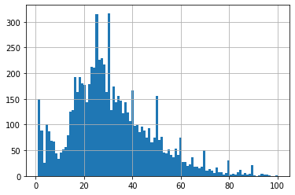

```python
labels.real_age.hist(bins=100)
```

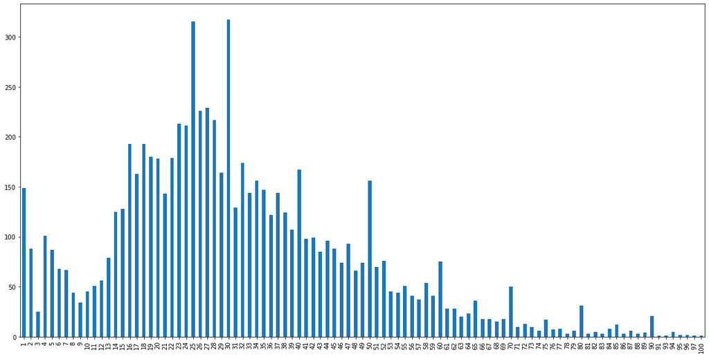

```python
labels.real_age.value_counts().sort_index().plot(kind='bar', figsize=(20, 10))
```

Распределение близко к нормальному, со смещением влево. Мы видим явное преобладание возраста 20-30 лет, с явными пиками на 25 и 30 годах. Также, есть просадка в районах 3 и 9 лет, а после 70 в целом фотографий очень мало, что затрудняет обучение

```python
features, target = next(gen_flow)
```

[figure not shown]

```python
fig = plt.figure(figsize=(10,10))
for i in range(16):
    fig.add_subplot(4, 4, i+1)
    plt.imshow(features[i])
    plt.xticks([])
    plt.yticks([])
    plt.tight_layout()
```

Фотографии разнообразные – здесь есть люди совершенно разных возрастов, а так же как семейные и личные фото, так и сцены из фильмов и публичные снимки. Условия съемки тоже различные, что добавляет баллов обученной модели (она сможет распознать людей в разных позах и при разном освещении)